# titanic

### 问题:

- 问题1:数据的结构是什么样的？
- 问题2:应该保留什么样的数据进行分析，舍弃哪些类型的数据？是否能从主观上排除一些随机数据？
- 问题3：离散值如何处理？
- 问题4：应该使用什么样的图表？

```python
import pandas as pd
import numpy as np
%matplotlib inline
```

```python
df=pd.read_csv("./train.csv")
```

```python
df.head()
```

|  | PassengerId | Survived | Pclass | Name | Sex | Age | SibSp | Parch | Ticket | Fare | Cabin | Embarked |
| --- | --- | --- | --- | --- | --- | --- | --- | --- | --- | --- | --- | --- |
| 0 | 1 | 0 | 3 | Braund, Mr. Owen Harris | male | 22.0 | 1 | 0 | A/5 21171 | 7.2500 | NaN | S |
| 1 | 2 | 1 | 1 | Cumings, Mrs. John Bradley (Florence Briggs Th... | female | 38.0 | 1 | 0 | PC 17599 | 71.2833 | C85 | C |
| 2 | 3 | 1 | 3 | Heikkinen, Miss. Laina | female | 26.0 | 0 | 0 | STON/O2. 3101282 | 7.9250 | NaN | S |
| 3 | 4 | 1 | 1 | Futrelle, Mrs. Jacques Heath (Lily May Peel) | female | 35.0 | 1 | 0 | 113803 | 53.1000 | C123 | S |
| 4 | 5 | 0 | 3 | Allen, Mr. William Henry | male | 35.0 | 0 | 0 | 373450 | 8.0500 | NaN | S |

### 问题1：数据的结构是什么样的？

回答:

- 数据包含若干离散值和连续值
- 生还率是度量，其余都是维度
- 生还率是离散值，维度存在若干连续值
- 生还率可以通过离散值列Survived计算出来，这一列的平均值就是生还率

### 问题2：应该保留哪些数据，舍弃那些数据？

回答:

- Name维度完全随机，对分析结果没有任何意义，舍弃
- Ticket维度舍弃,和Name维度意义，这一列数据是完全随机的
- PassengeId 是列标号，在分析时舍弃

### 问题3： 离散值如何处理?

回答: 作为度量的生还率是离散值，因为分析是为了找出和生还率关联性最高的维度 ，因此将各个维度分组后，计算生还率平均值，这样场景下整型离散值是可以直接使用的

### 分析1

```python
def plotRate(feature):
    """
    绘制不同feature不同tage的平均生还率
    """
#     按维度进行分组并求出平均值
    min=df.groupby(feature)["Survived"].mean()
#      创建dataFrame
    min=pd.DataFrame(data=min)
#     绘制条形图
    min.plot(kind="bar")
```

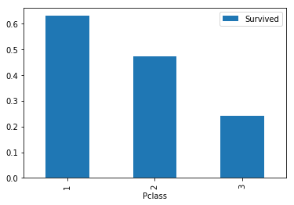

```python
# 绘制Pclass分组后的条形图
plotRate("Pclass")
```

```python
# 绘制Sex分组后的生还率
```

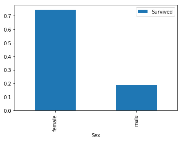

```python
plotRate("Sex")
```

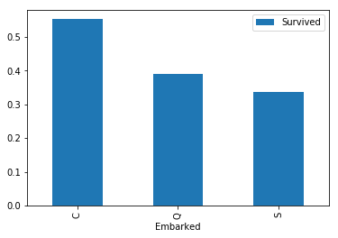

```python
#绘制Embarked分组后的条形图
plotRate("Embarked")
```

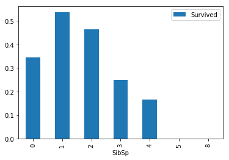

```python
# 绘制Slibsp分组后的条形图
plotRate("SibSp")
```

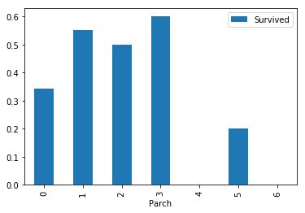

```python
#绘制Parch分组后的条形图
plotRate("Parch")
```

### 下面分析几个连续值

- 年龄 age
- 票价 Fare
- 对年龄的分析，因为survived是离散值，并且年龄也是维度而非度量，因此采用将年龄分组，并求出各年龄段的平均生还率的方法

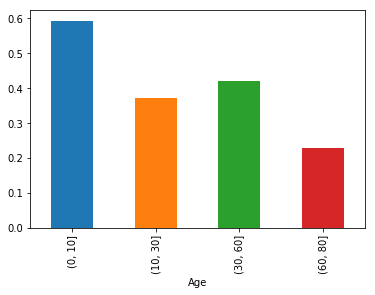

```python
age_group=pd.cut(df["Age"],[0,10,30,60,80])
df.groupby(age_group)["Survived"].mean().plot(kind="bar")
```

- 结论2：年龄与生还率存在一定的关系，十岁以下儿童生还率最高,老人生还率最低

#### 对票价的分析才用和年龄同样的方法，先分组，再求平均生还率

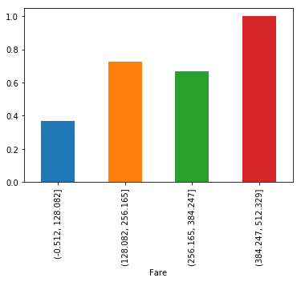

```python
fare_group=pd.cut(df["Fare"],4)
df.groupby(fare_group)["Survived"].mean().plot(kind="bar")
```

- 结论3： 票价与生还率相关性强，低票价生还率低，高票价生还率高